# Cut the R Learning Curve

Steph Locke (@SteffLocke)

2017-04-20

# Steph Locke

- Locke Data
- Presenter on Data Science, BI, and DataOps
- Microsoft Data Platform MVP
- User group leader: [MSFT Stack](http://www.meetup.com/MSFT%20Stack) & [CaRdiff](http://www.meetup.com/Cardiff-R-User-Group/)
- Conference organiser: [satRdays](http://planning.satrdays.org) & [Battle of the Beards](http://battleofthebeards.info)

github.com/StephLocke | itsalocke.com | [T: SteffLocke](https://twitter.com/stefflocke)

# Agenda

# Agenda

- R
- R + Microsoft
- RefresheR
- Super R
- R for Reporting
- Develop R
- Administer R
- Wrap up

# R

# R

> R is an integrated suite of software facilities for data manipulation, calculation and graphical display
- Open source
- In-memory & single-core (by default)
- Multi-platform
- Extensible environment
- Delivered by the [R Foundation](https://www.r-project.org/foundation/), supported by the [R Consortium](https://www.r-consortium.org/), grown by R developers
- [r-project.org](http://www.r-project.org/)

# Setup on Windows

- Get R
- Get R Tools
- Get RStudio or Visual Studio + VS R Tools

# There’s a package for that

- R is extended with packages of functionality
- More than 8,000 active packages according to [MetaCRAN](http://www.r-pkg.org/)
- [Comprehensive R Archive Network (CRAN)](https://cran.r-project.org/)
- [Github](https://github.com) via devtools

# How it hangs together

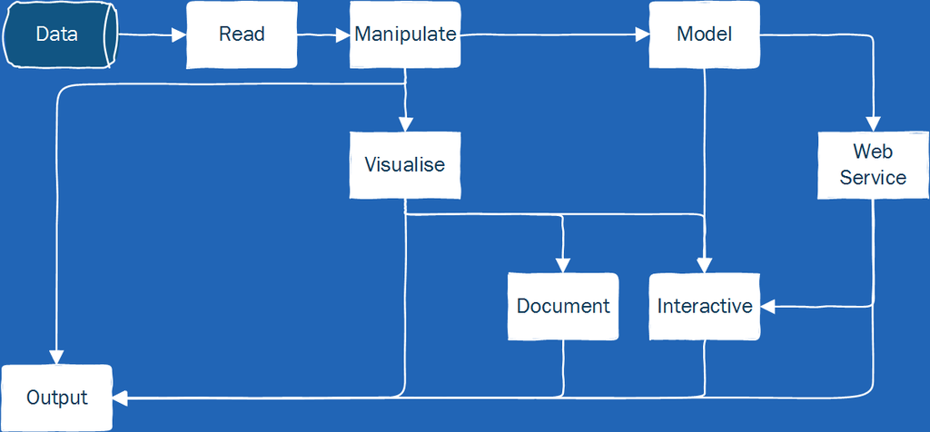

# How it hangs together

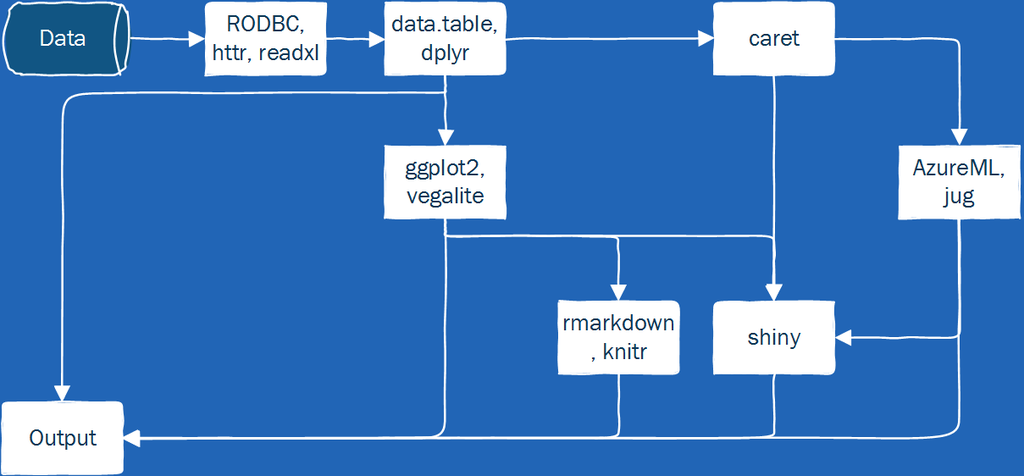

# Next steps

1. Check out the [R website](http://www.r-project.org/)
2. Install [R](http://www.r-project.org/) & [RStudio](http://rstudio.com) (or [R Tools for Visual Studio](https://www.visualstudio.com/en-us/features/rtvs-vs.aspx))

# R + Microsoft

# Microsoft R Server

- Formerly, Revolution R for Enterprise
- Available on Windows and Linux
- Specialised connectors available for SQL Server, Hadoop, Oracle, & Teradata

# AzureML

- Uses R throughout

# PowerBI

- R as a data source
- Use R for data visualisations
- Any R variant

# SQL Server

- Call R from inside SQL

# RefresheR

# Syntax

| Action | Operator | Example |
| --- | --- | --- |
| Create / update a variable | <- | `a <- 10` |
| Comment | # | `# This is my comment` |
| Help | ? | `?mean` |
| Identifier | ` | `` `1`<-2 `` |
| Get a component e.g a data.frame column | $ | `iris$Sepal.Length` |
| Reference positions within an object | [ ] | iris[ 1 , 1] |

# Objects

- Vector
- Matrix
- Array
- List
- data.frame

# Next steps

- Go through the first sections of the [R for Microsoft Data Platform](http://stephlocke.github.io/RMSFTDP) pre-con
- Try the [datacamp R intro course](https://campus.datacamp.com/courses/free-introduction-to-r)

# Super R

# data.table

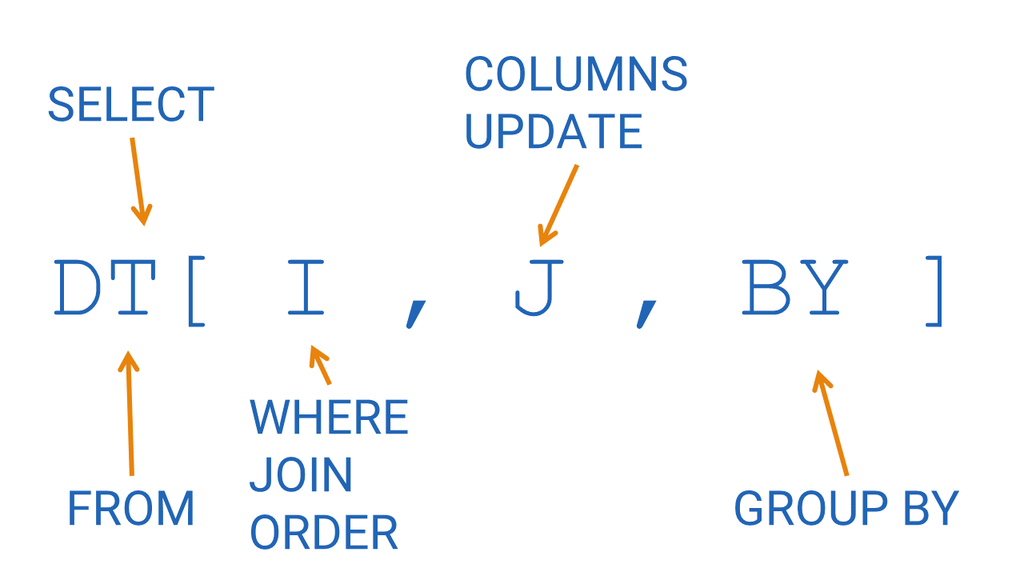

# data.table

1. Super-fast slicing & dicing
2. Low memory footprint vs data.frames
3. Fast joins
4. Auto-indexing
5. Many saved characters!
6. Active dev

# data.table

| Task | How |
| --- | --- |
| Read CSV | `irisDT <- fread(“iris.csv”)` |
| Return everything | `irisDT irisDT[ ]` |
| Select columns | `irisDT[ , .(Sepal.Length, Sepal.Width) ]` |
| Restrict rows | `irisDT[ Sepal.Length >=5 , ]` |
| Aggregate | `irisDT[ , mean(Sepal.Length)]` |
| Aggregate by group | `irisDT[ , mean(Sepal.Length) , Species ]` |
| Count | `irisDT[ , .N ]` |

# The “Hadleyverse”

[Hadley Wickham](http://had.co.nz/), insanely prolific developer of R packages has produced a great ecosystem:

- httr
- ggplot2
- purrr
- readxl
- haven
- dplyr
- rvest
- …

# dplyr

- filter() (and slice())
- arrange()
- select() (and rename())
- distinct()
- mutate() (and transmute())
- summarise()
- sample_n() and sample_frac()

# dplyr

1. Relatively clear verbs
2. Quite easy to get started with
3. Verbose

# ggplot2

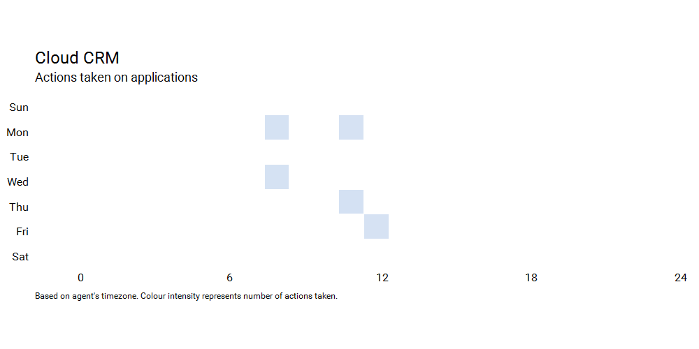

# ggplot2

1. Clean conceptual implementation
2. Highly customisable
3. Simple to start with
4. Big ecosystem

# ggplot2

| Term | Explanation | Example(s) |
| --- | --- | --- |
| **plot** | A plot using the grammar of graphics | `ggplot()` |
| **aes**thetics | attributes of the chart | colour, x, y |
| mapping | relating a column in your data to an aesthetic |  |
| **stat**istical transformation | a translation of the raw data into a refined summary | `stat_density()` |
| **geom**etry | the display of aesthetics | `geom_line()`, `geom_bar()` |
| **scale** | the range of values | axes, legends |
| **coord**inate system | how geometries get laid out | `coord_flip()` |
| **facet** | a means of subsetting the chart | `facet_grid()` |
| **theme** | display properties | `theme_minimal()` |

# caret

> A single point of contact for myriad statistical & machine learning algorithms
- Plus handy data prep!
- Find out more at [caret homepage](http://topepo.github.io/caret/)

# AzureML

> Interact with AzureML in R
1. No GUI
2. All the development environments of R
3. Consume AzureML webservice

# rmarkdown

> Write markdown, interweave code
1. Data provenance
2. Ease of documenting & developing solutions
3. Extendible & customisable

# miniCRAN

> Make your own CRAN
1. R interface
2. Control over packages
3. Internal package deployment

# Next steps

1. Play with the popular packages
2. Look at [CRAN task views](https://cran.r-project.org/web/views/)
3. Ask for recommendations!

# R for Reporting

# Types of reports

- Interactive
- Static

# Interactive reports

- shiny
- flexdashboards

# Static reports

- rmarkdown
- knitr

# I’m going to show off

# Develop R

# Utility packages

- testthat
- devtools (useful for other things)
- microbenchmark
- packrat

# Package development

```r
library(devtools)
pkg<-"newPackage"
create(pkg)

library(devtools) # Open the project!
add_test_infrastructure() # Add unit test framework
add_travis() # Add CI framework
use_vignette() # Add folder for macro-level help files
use_package_doc() # Add file for providing info about your package
use_readme_rmd() # Make a README!
```

# What to unit test

1. A single set of values that represent “normal” and expect this matches a correct answer
2. A dataset that represents “normal” and expecting this to match correct answers
3. Various permutations of bad input values and expect errors (ideally specific error messages)
4. Edge cases that cover extreme values or boundaries for any inequalities or conditions
5. Any bugs or compatibility issues

# How to test

```r
myfunc<-function(a=1,b=2,c="blah"){
stopifnot(is.numeric(a), is.numeric(b), is.character(c))
d<-ifelse(a<0,a*b,a/b)
e<-paste0(c,d)
return(e)
}
library(testthat)
# Add a high-level name for group of tests, typically the function name
context("myfunc")

# Simplest test
test_that("Defaults return expected result",{
  result<-myfunc()
  check<-"blah0.5"
  expect_equal(result,check)
})
```

# Next steps

1. Read Hadley’s [Package Development guide](http://r-pkgs.had.co.nz/)
2. Practice!

# Administer R

# Infrastructure

- Windows or Linux?
- Linux!
- Because …
- RStudio Server
- System Dependencies

# Infrastructure

- High RAM
- CPU should be decent
- Physical storage can be low
- Virus scanning not a problem
- AD auth (fairly simple)
- File share availability
- Backups or scripted builds?

# R

- Microsoft R or base R?
- It depends!
- Need cutting edge R & packages?
- Need extra computational speed or connectors?

# R & Packages

- Regular updates required
- Unit tests of key behaviours should be done
- Dev environments always a plus!
- miniCRAN

# Deployment

- Ad-hoc facilities
- Via Continuous Deployment

# Next steps

- Learn some [Linux fundamentals](http://linuxsurvival.com/)
- Determine what sort of capacity requirements are needed

# Wrap up

# Covered

- R overview
- R + Microsoft
- RefresheR
- Super R
- R for Reporting
- Develop R
- Administer R

# Next steps

- Get the deck & more at [bit.ly/stephsR](https://stephlocke.github.io/Rtraining)
- Follow up the Next Steps sections
- Let me know how you get on: @SteffLocke